# Analyse_donnees

L’objectif de ce notebook est de mieux comprendre les données et analyses de l’article *Mutation dynamics and fitness effects followed in single cells*, par Lydia Robert, Jean Ollion, Jerome Robert, Xiaohu Song, Ivan Matic et Marina Elez (Science, 2018).

# Exploration des données

```r
library("ggplot2")
```

## Données d’Accumulation de Mutations : data_microMA

### Description des fichiers

The folder contains 4 files giving the evolution of growth rate during one representative $\mu$MA experiment for 4 different strains, *mutH*, *mutT*, WT, MF1 (dataset_microMA_…) . Each column contains the values of one variable (time, generation or growth rate) for each time step for the mother cell of a single microchannel. The first two lines (i.e. first two values for each column) give respectively the index of the field of view and the index of the microchannel (~15channels for each field of view).

```r
microMA_WT <- read.csv2("doi_10/All_data/data_microMA/dataset_microMA_WT.csv")
microMA_MutH <- read.csv2("doi_10/All_data/data_microMA/dataset_microMA_MutH.csv")
microMA_MutT <- read.csv2("doi_10/All_data/data_microMA/dataset_microMA_MutT.csv")
microMA_MF1 <- read.csv2("doi_10/All_data/data_microMA/dataset_microMA_MF1.csv")

# Split the channel information (first 2 lines) from the growth rates
microMA_WT_channels <- microMA_WT[c(1,2),]
microMA_WT <- microMA_WT[-c(1,2),]
microMA_MutH_channels <- microMA_MutH[c(1,2),]
microMA_MutH <- microMA_MutH[-c(1,2),]
microMA_MutT_channels <- microMA_MutT[c(1,2),]
microMA_MutT <- microMA_MutT[-c(1,2),]
microMA_MF1_channels <- microMA_MF1[c(1,2),]
microMA_MF1 <- microMA_MF1[-c(1,2),]

microMA_MutH[1:6,1:9]
```

```
##   time generation growth.rate time.1 generation.1 growth.rate.1 time.2
## 3    0          1  0.03526965      0            1    0.03202591      0
## 4    4          1  0.03526965      4            1    0.03202591      4
## 5    8          2  0.03247045      8            1    0.03202591      8
## 6   12          2  0.03247045     12            1    0.03202591     12
## 7   16          2  0.03247045     16            2    0.03367152     16
## 8   20          2  0.03247045     20            2    0.03367152     20
##   generation.2 growth.rate.2
## 3            1    0.02811950
## 4            1    0.02811950
## 5            2    0.02680181
## 6            2    0.02680181
## 7            2    0.02680181
## 8            2    0.02680181
```

The folder also contains 4 files giving data on mortality of the mother cell for these experiments and one file with the mortality data for one representative experiment with the pMQ strain (induced with arabinose). For WT and mutH strains, the first 2 columns gives the index of the field of view and the index of the microchannel. The two last columns for WT and mutH and the two columns for mutT, MF1 and pMQ indicates the final state of the mother cell and the last frame. Several cases can occur :

1. the mother cell can die during the experiment (final state=0, last frame=frame of the last division),
2. it can stay alive and be imaged until the end of the experiment (final state=2, last frame=last frame of the movie),
3. ?
4. or imaging can stop before the end of the experiment for instance if the cells escape the channel (final state=4, last frame=last frame where the mother cell is imaged).

```r
mortality_WT <- read.csv2("doi_10/All_data/data_microMA/mortality_WT.csv")
mortality_MutH <- read.csv2("doi_10/All_data/data_microMA/mortality_MutH.csv")
mortality_MutT <- read.csv2("doi_10/All_data/data_microMA/mortality_mutT.csv")
mortality_MF1 <- read.csv2("doi_10/All_data/data_microMA/mortality_MF1.csv")
mortality_pMQ <- read.csv2("doi_10/All_data/data_microMA/mortality_pMQara.csv")

# Name columns
names(mortality_WT) <- c("Field.view", "Microchannel", "Final.state", "Final.frame")
names(mortality_MutH) <- c("Field.view", "Microchannel", "Final.state", "Final.frame")

# Remove NA columns
mortality_MutT <- mortality_MutT[-which(sapply(mortality_MutT, function(x)all(is.na(x))))]
mortality_pMQ <- mortality_pMQ[-which(sapply(mortality_pMQ, function(x)all(is.na(x))))]

# Consider the final state as a factor
mortality_WT$Final.state <- as.factor(mortality_WT$Final.state)
mortality_MutH$Final.state <- as.factor(mortality_MutH$Final.state)
mortality_MutT$Final.state <- as.factor(mortality_MutT$Final.state)
mortality_MF1$Final.state <- as.factor(mortality_MF1$Final.state)
mortality_pMQ$Final.state <- as.factor(mortality_pMQ$Final.state)

# Remove lines with NAs
mortality_WT_NA <- mortality_WT[is.na(mortality_WT$Final.state),]
mortality_WT <- mortality_WT[!is.na(mortality_WT$Final.state),]
mortality_MutH_NA <- mortality_MutH[is.na(mortality_MutH$Final.state),]
mortality_MutH <- mortality_MutH[!is.na(mortality_MutH$Final.state),]
mortality_pMQ_NA <- mortality_pMQ[is.na(mortality_pMQ$Final.state),]
mortality_pMQ <- mortality_pMQ[!is.na(mortality_pMQ$Final.state),]

head(mortality_MutH)
```

```
##   Field.view Microchannel Final.state Final.frame
## 1          1            2           4         441
## 2          1            3           4         346
## 3          1            4           0         402
## 4          1            5           2        1000
## 5          1            6           0         359
## 6          1            7           0         770
```

```r
head(mortality_MutT)
```

```
##   Final.state Final.frame
## 1           0         695
## 2           0         752
## 3           0         932
## 4           0         212
## 5           0          16
## 6           0         807
```

The folder contains also a file called “last_frames_for_microMA_analysis_MF1”which contains 4 columns which indicate : the index of the field of view, the index of the microchannel, the final frame for analysis and the final state (“alive” or “dead”). Here the final frame for analysis is the last frame where the cell is imaged if final state=alive but if the cell dies, it gives the frame where growth rate analysis should stop (~10 generations before death).

```r
last_frames_for_microMA_analysis_MF1 <- read.csv2("doi_10/All_data/data_microMA/last_frames_for_microMA_analysis_MF1.csv")

head(last_frames_for_microMA_analysis_MF1)
```

```
##   Position Microchannel Final.frame.for.analysis final.state
## 1     xy40            3                      667       alive
## 2     xy40           17                      667       alive
## 3     xy40            6                      614       alive
## 4     xy40            8                      667       alive
## 5     xy40           12                      184       alive
## 6     xy40            1                      148       alive
```

### Mortality

#### MutH

```r
summary(mortality_MutH)
```

```
##    Field.view      Microchannel Final.state  Final.frame
##  Min.   :  1.00   Min.   : 1    0:810       Min.   :   0.0
##  1st Qu.: 25.00   1st Qu.: 4    2:398       1st Qu.: 418.5
##  Median : 50.00   Median : 8    3:  1       Median : 700.0
##  Mean   : 50.19   Mean   : 8    4:271       Mean   : 659.0
##  3rd Qu.: 75.00   3rd Qu.:12                3rd Qu.:1000.0
##  Max.   :100.00   Max.   :15                Max.   :1000.0
```

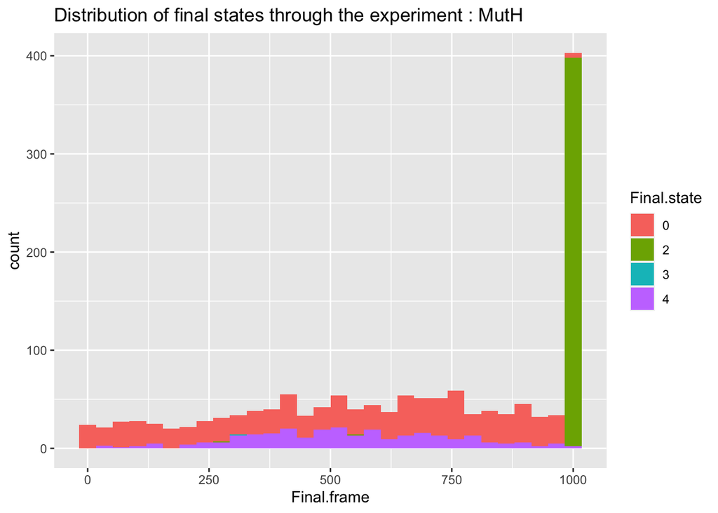

```r
ggplot(mortality_MutH, aes(x=Final.frame, fill=Final.state))+
  geom_histogram(bins = 30) +
  ggtitle("Distribution of final states through the experiment : MutH")
```

```r
last_frame_MutH <- max(mortality_MutH$Final.frame)
survival_frame <- function(i, dataset){               # Proportion
  return (mean(dataset$Final.frame>=i, na.rm = T))
}

mortality_MutH_noEscape <- mortality_MutH[mortality_MutH$Final.state != 4,]

survival_MutH <- data.frame(Time = 0:last_frame_MutH/60*4,  # One frame every 4 minutes
                            Survival = sapply(0:last_frame_MutH, survival_frame, dataset=mortality_MutH),
                            # Correct for escaped bacteria
                            Survival_noEscape = sapply(0:last_frame_MutH, survival_frame, dataset=mortality_MutH_noEscape))
```

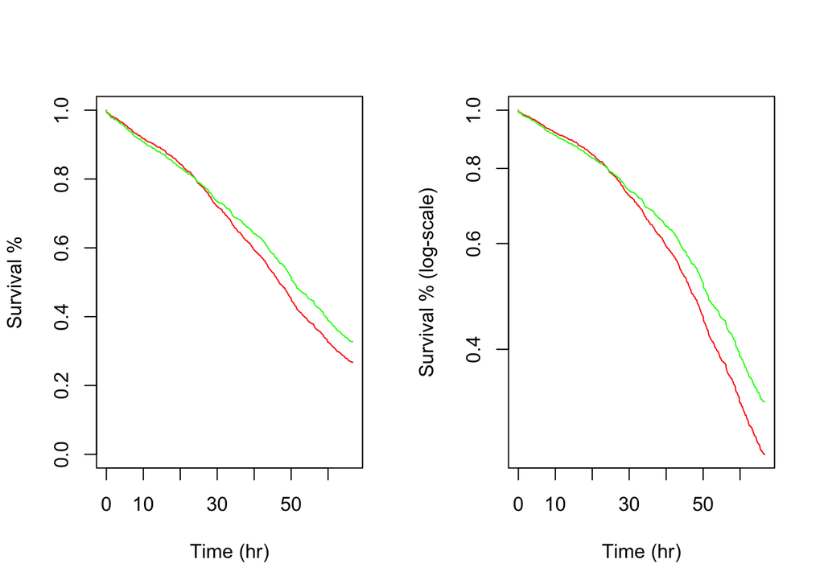

```r
par(mfrow=c(1,2))
plot(x=survival_MutH$Time,
     y=survival_MutH$Survival,
     type="l",
     col="red",
     xlab = "Time (hr)",
     ylab="Survival %",
     ylim = c(0.0001,1))
lines(x=survival_MutH$Time, y=survival_MutH$Survival_noEscape, col="green")

plot(x=survival_MutH$Time,
     y=survival_MutH$Survival,
     type="l",
     col="red",
     xlab = "Time (hr)",
     ylab="Survival % (log-scale)",
     # ylim = c(0.1,1),
     log="y")
lines(x=survival_MutH$Time, y=survival_MutH$Survival_noEscape, col="green")
```

#### All lines

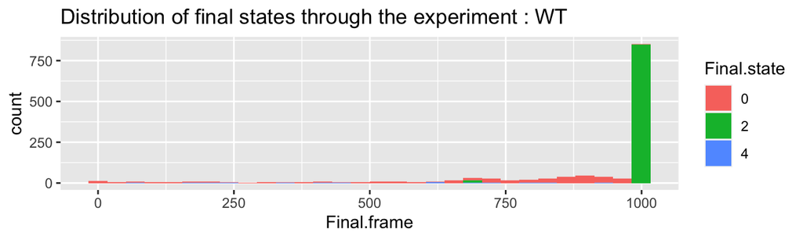

```r
ggplot(mortality_WT, aes(x=Final.frame, fill=Final.state)) +
  geom_histogram(bins = 30) +
  ggtitle("Distribution of final states through the experiment : WT")
```

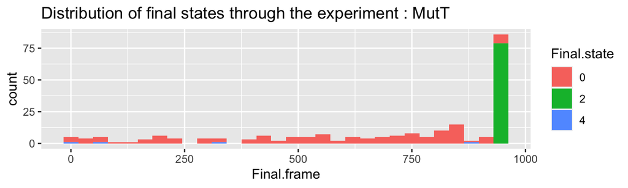

```r
ggplot(mortality_MutT, aes(x=Final.frame, fill=Final.state)) +
  geom_histogram(bins = 30) +
  ggtitle("Distribution of final states through the experiment : MutT")
```

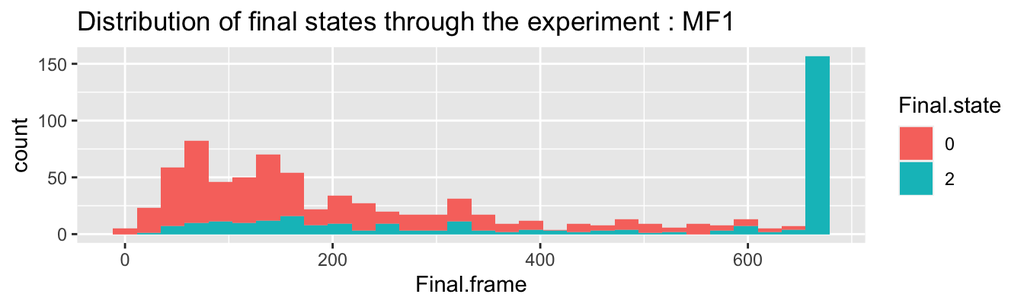

```r
ggplot(mortality_MF1, aes(x=Final.frame, fill=Final.state)) +
  geom_histogram(bins = 30) +
  ggtitle("Distribution of final states through the experiment : MF1")
```

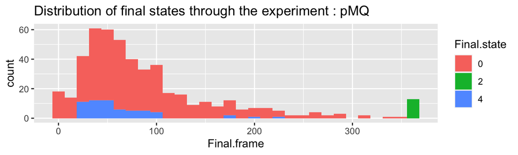

```r
ggplot(mortality_pMQ, aes(x=Final.frame, fill=Final.state)) +
  geom_histogram(bins = 30) +
  ggtitle("Distribution of final states through the experiment : pMQ")
```

```r
last_frame_WT <- max(mortality_WT$Final.frame)
last_frame_MutT <- max(mortality_MutT$Final.frame)
last_frame_MF1 <- max(mortality_MF1$Final.frame)
last_frame_pMQ <- max(mortality_pMQ$Final.frame)

mortality_WT_noEscape <- mortality_WT[mortality_WT$Final.state != 4,]
mortality_MutT_noEscape <- mortality_MutT[mortality_MutT$Final.state != 4,]
mortality_MF1_noEscape <- mortality_MF1[mortality_MF1$Final.state != 4,]
mortality_pMQ_noEscape <- mortality_pMQ[mortality_pMQ$Final.state != 4,]

survival_WT <- data.frame(Time = 0:last_frame_WT/60*4,  # One frame every 4 minutes
                          Survival = sapply(0:last_frame_WT, survival_frame, dataset=mortality_WT),
                          Survival_noEscape = sapply(0:last_frame_WT, survival_frame, dataset=mortality_WT_noEscape))
survival_MutT <- data.frame(Time = 0:last_frame_MutT/60*4,
                            Survival = sapply(0:last_frame_MutT, survival_frame, dataset=mortality_MutT),
                            Survival_noEscape = sapply(0:last_frame_MutT, survival_frame, dataset=mortality_MutT_noEscape))
survival_MF1 <- data.frame(Time = 0:last_frame_MF1/60*4,
                           Survival = sapply(0:last_frame_MF1, survival_frame, dataset=mortality_MF1),
                           Survival_noEscape = sapply(0:last_frame_MF1, survival_frame, dataset=mortality_MF1_noEscape))
survival_pMQ <- data.frame(Time = 0:last_frame_pMQ/60*4,
                           Survival = sapply(0:last_frame_pMQ, survival_frame, dataset=mortality_pMQ),
                           Survival_noEscape = sapply(0:last_frame_pMQ, survival_frame, dataset=mortality_pMQ_noEscape))
```

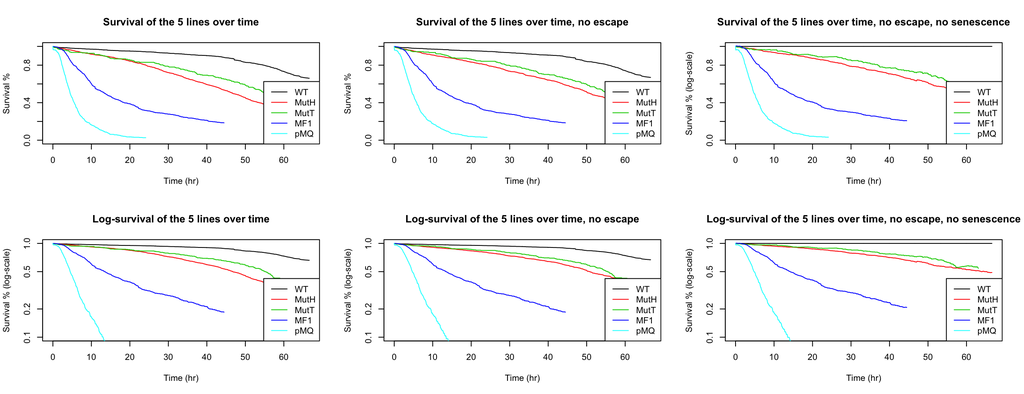

```r
par(mfrow=c(2,3))
plot(x=survival_WT$Time,
     y=survival_WT$Survival,
     type="l",
     col=1,
     xlab = "Time (hr)",
     ylab="Survival %",
     ylim = c(0,1),
     main = "Survival of the 5 lines over time")
lines(x=survival_MutH$Time, y=survival_MutH$Survival, col=2)
lines(x=survival_MutT$Time, y=survival_MutT$Survival, col=3)
lines(x=survival_MF1$Time, y=survival_MF1$Survival, col=4)
lines(x=survival_pMQ$Time, y=survival_pMQ$Survival, col=5)
legend("bottomright", legend = c("WT", "MutH", "MutT", "MF1", "pMQ"), col=1:5, lty=1)

plot(x=survival_WT$Time,
     y=survival_WT$Survival_noEscape,
     type="l",
     col=1,
     xlab = "Time (hr)",
     ylab="Survival %",
     ylim = c(0,1),
     main = "Survival of the 5 lines over time, no escape")
lines(x=survival_MutH$Time, y=survival_MutH$Survival_noEscape, col=2)
lines(x=survival_MutT$Time, y=survival_MutT$Survival_noEscape, col=3)
lines(x=survival_MF1$Time, y=survival_MF1$Survival_noEscape, col=4)
lines(x=survival_pMQ$Time, y=survival_pMQ$Survival_noEscape, col=5)
legend("bottomright", legend = c("WT", "MutH", "MutT", "MF1", "pMQ"), col=1:5, lty=1)

plot(x=survival_WT$Time,
     y=survival_WT$Survival_noEscape/survival_WT$Survival_noEscape,
     type="l",
     col=1,
     xlab = "Time (hr)",
     ylab="Survival % (log-scale)",
     ylim = c(0,1),
     main = "Survival of the 5 lines over time, no escape, no senescence")
lines(x=survival_MutH$Time, y=survival_MutH$Survival_noEscape/survival_WT$Survival_noEscape[1:length(survival_MutH$Survival_noEscape)], col=2)
lines(x=survival_MutT$Time, y=survival_MutT$Survival_noEscape/survival_WT$Survival_noEscape[1:length(survival_MutT$Survival_noEscape)], col=3)
lines(x=survival_MF1$Time, y=survival_MF1$Survival_noEscape/survival_WT$Survival_noEscape[1:length(survival_MF1$Survival_noEscape)], col=4)
lines(x=survival_pMQ$Time, y=survival_pMQ$Survival_noEscape/survival_WT$Survival_noEscape[1:length(survival_pMQ$Survival_noEscape)], col=5)
legend("bottomright", legend = c("WT", "MutH", "MutT", "MF1", "pMQ"), col=1:5, lty=1)

plot(x=survival_WT$Time,
     y=survival_WT$Survival,
     type="l",
     col=1,
     xlab = "Time (hr)",
     ylab="Survival % (log-scale)",
     ylim = c(0.1,1),
     log = "y",
     main = "Log-survival of the 5 lines over time")
lines(x=survival_MutH$Time, y=survival_MutH$Survival, col=2)
lines(x=survival_MutT$Time, y=survival_MutT$Survival, col=3)
lines(x=survival_MF1$Time, y=survival_MF1$Survival, col=4)
lines(x=survival_pMQ$Time, y=survival_pMQ$Survival, col=5)
legend("bottomright", legend = c("WT", "MutH", "MutT", "MF1", "pMQ"), col=1:5, lty=1)

plot(x=survival_WT$Time,
     y=survival_WT$Survival_noEscape,
     type="l",
     col=1,
     xlab = "Time (hr)",
     ylab="Survival % (log-scale)",
     ylim = c(0.1,1),
     log="y",
     main = "Log-survival of the 5 lines over time, no escape")
lines(x=survival_MutH$Time, y=survival_MutH$Survival_noEscape, col=2)
lines(x=survival_MutT$Time, y=survival_MutT$Survival_noEscape, col=3)
lines(x=survival_MF1$Time, y=survival_MF1$Survival_noEscape, col=4)
lines(x=survival_pMQ$Time, y=survival_pMQ$Survival_noEscape, col=5)
legend("bottomright", legend = c("WT", "MutH", "MutT", "MF1", "pMQ"), col=1:5, lty=1)

plot(x=survival_WT$Time,
     y=survival_WT$Survival_noEscape/survival_WT$Survival_noEscape,
     type="l",
     col=1,
     xlab = "Time (hr)",
     ylab="Survival % (log-scale)",
     ylim = c(0.1,1),
     log="y",
     main = "Log-survival of the 5 lines over time, no escape, no senescence")
lines(x=survival_MutH$Time, y=survival_MutH$Survival_noEscape/survival_WT$Survival_noEscape[1:length(survival_MutH$Survival_noEscape)], col=2)
lines(x=survival_MutT$Time, y=survival_MutT$Survival_noEscape/survival_WT$Survival_noEscape[1:length(survival_MutT$Survival_noEscape)], col=3)
lines(x=survival_MF1$Time, y=survival_MF1$Survival_noEscape/survival_WT$Survival_noEscape[1:length(survival_MF1$Survival_noEscape)], col=4)
lines(x=survival_pMQ$Time, y=survival_pMQ$Survival_noEscape/survival_WT$Survival_noEscape[1:length(survival_pMQ$Survival_noEscape)], col=5)
legend("bottomright", legend = c("WT", "MutH", "MutT", "MF1", "pMQ"), col=1:5, lty=1)
```

### Growth rates

#### MutH

```r
head(microMA_MutH[,1:9])
```

```
##   time generation growth.rate time.1 generation.1 growth.rate.1 time.2
## 3    0          1  0.03526965      0            1    0.03202591      0
## 4    4          1  0.03526965      4            1    0.03202591      4
## 5    8          2  0.03247045      8            1    0.03202591      8
## 6   12          2  0.03247045     12            1    0.03202591     12
## 7   16          2  0.03247045     16            2    0.03367152     16
## 8   20          2  0.03247045     20            2    0.03367152     20
##   generation.2 growth.rate.2
## 3            1    0.02811950
## 4            1    0.02811950
## 5            2    0.02680181
## 6            2    0.02680181
## 7            2    0.02680181
## 8            2    0.02680181
```

```r
summary(microMA_MutH[,1:9])
```

```
##       time        generation      growth.rate          time.1
##  Min.   :   0   Min.   :  1.00   Min.   :0.01835   Min.   :   0
##  1st Qu.: 999   1st Qu.: 45.00   1st Qu.:0.02770   1st Qu.: 999
##  Median :1998   Median : 90.00   Median :0.02883   Median :1998
##  Mean   :1998   Mean   : 90.82   Mean   :0.02974   Mean   :1998
##  3rd Qu.:2997   3rd Qu.:136.00   3rd Qu.:0.03127   3rd Qu.:2997
##  Max.   :3996   Max.   :183.00   Max.   :0.07248   Max.   :3996
##   generation.1   growth.rate.1         time.2      generation.2
##  Min.   :  1.0   Min.   :0.01148   Min.   :   0   Min.   :  1.00
##  1st Qu.: 36.0   1st Qu.:0.01650   1st Qu.: 999   1st Qu.: 48.75
##  Median : 63.0   Median :0.01753   Median :1998   Median : 97.00
##  Mean   : 63.8   Mean   :0.01859   Mean   :1998   Mean   : 91.61
##  3rd Qu.: 92.0   3rd Qu.:0.01944   3rd Qu.:2997   3rd Qu.:140.00
##  Max.   :122.0   Max.   :0.03386   Max.   :3996   Max.   :165.00
##  growth.rate.2
##  Min.   :-0.0009553
##  1st Qu.: 0.0252990
##  Median : 0.0290788
##  Mean   : 0.0240472
##  3rd Qu.: 0.0314002
##  Max.   : 0.0927149
```

```r
microMA_MutH_growthRates <- microMA_MutH[seq(3, dim(microMA_MutH)[1], 3)]

moment_expectation <- function(k, dataset){
  return (rowMeans(dataset**k, na.rm = T))
}

k_values <- 1:10
moments_expectations_MutH <- data.frame(sapply(k_values, moment_expectation, dataset=microMA_MutH_growthRates))
names(moments_expectations_MutH) <- paste("k.", k_values, sep = "")
head(moments_expectations_MutH)
```

```
##          k.1          k.2          k.3          k.4          k.5          k.6
## 3 0.03137447 0.0010032700 3.251881e-05 1.066829e-06 3.539456e-08 1.186858e-09
## 4 0.03130396 0.0009998646 3.235306e-05 1.059208e-06 3.505972e-08 1.172581e-09
## 5 0.03133240 0.0010003611 3.226211e-05 1.050351e-06 3.450651e-08 1.143443e-09
## 6 0.03127231 0.0009965875 3.208534e-05 1.043040e-06 3.422552e-08 1.133199e-09
## 7 0.03114305 0.0009878136 3.163678e-05 1.022574e-06 3.334669e-08 1.096837e-09
## 8 0.03121328 0.0009931178 3.191967e-05 1.035682e-06 3.391273e-08 1.120357e-09
##            k.7          k.8          k.9         k.10
## 3 4.020415e-11 1.375217e-12 4.748269e-14 1.654292e-15
## 4 3.960677e-11 1.350511e-12 4.646825e-14 1.612815e-15
## 5 3.820324e-11 1.286428e-12 4.364179e-14 1.491033e-15
## 6 3.784594e-11 1.274498e-12 4.326276e-14 1.479768e-15
## 7 3.637811e-11 1.216262e-12 4.098122e-14 1.391229e-15
## 8 3.733480e-11 1.254727e-12 4.251900e-14 1.452577e-15
```

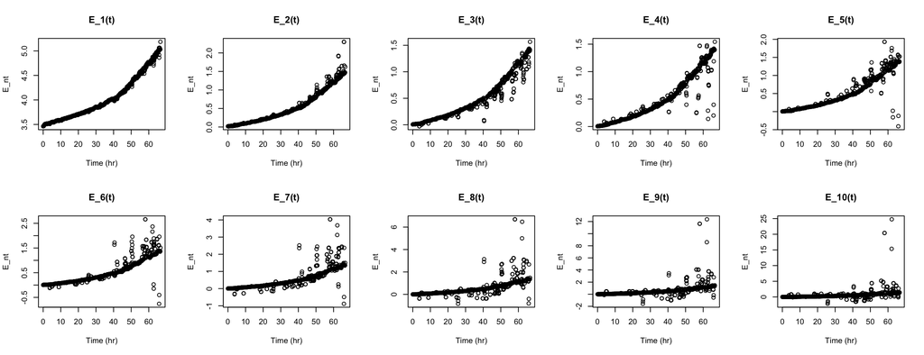

```r
log_choose <- function(k, n, moments_expectations){
  return ((-1)**k*choose(n,k)*log(moments_expectations[,k]))
}

par(mfrow = c(2,5))
for (n in 1:10){
  E_nt <- rowSums(sapply(1:n, log_choose, n=n, moments_expectations=moments_expectations_MutH))
  plot(x = microMA_MutH$time/60,
       y = E_nt,
       xlab = "Time (hr)",
       main = paste("E_", n, "(t)", sep = ""))
}
```

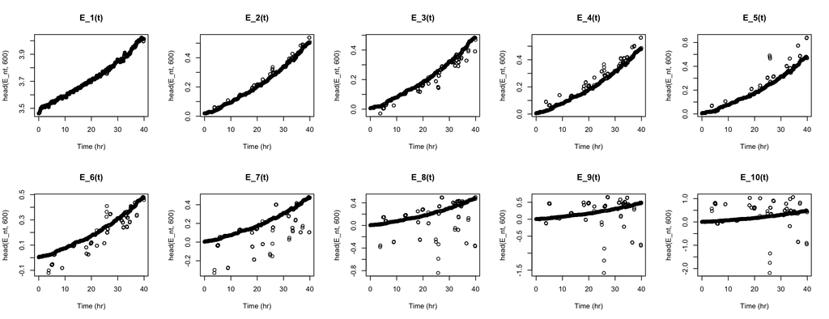

```r
par(mfrow = c(2,5))
for (n in 1:10){
  E_nt <- rowSums(sapply(1:n, log_choose, n=n, moments_expectations=moments_expectations_MutH))
  plot(x = head(microMA_MutH$time/60, 600),
       y = head(E_nt, 600),
       xlab = "Time (hr)",
       main = paste("E_", n, "(t)", sep = ""))
}
```

#### WT

```r
head(microMA_WT[,1:9])
```

```
##   time generation growth.rate time.1 generation.1 growth.rate.1 time.2
## 3    0          1  0.01553294      0            1            NA      0
## 4    4          1  0.01553294      4            2    0.03227775      4
## 5    8          2  0.03122056      8            2    0.03227775      8
## 6   12          2  0.03122056     12            2    0.03227775     12
## 7   16          2  0.03122056     16            2    0.03227775     16
## 8   20          2  0.03122056     20            2    0.03227775     20
##   generation.2 growth.rate.2
## 3            1            NA
## 4            2    0.03030216
## 5            2    0.03030216
## 6            2    0.03030216
## 7            2    0.03030216
## 8            2    0.03030216
```

```r
microMA_WT_growthRates <- microMA_WT[seq(3, dim(microMA_WT)[1], 3)]

k_values <- 1:10
moments_expectations_WT <- data.frame(sapply(k_values, moment_expectation, dataset=microMA_WT_growthRates))
names(moments_expectations_WT) <- paste("k.", k_values, sep = "")
head(moments_expectations_WT)
```

```
##          k.1         k.2          k.3          k.4          k.5          k.6
## 3 0.04042723 0.003156244 5.905593e-04 1.748746e-04 6.102199e-05 2.292541e-05
## 4 0.03860821 0.002765079 4.872849e-04 1.422165e-04 4.950406e-05 1.859016e-05
## 5 0.03470470 0.001544387 1.011044e-04 1.004379e-05 1.312441e-06 1.971840e-07
## 6 0.03282946 0.001308177 7.368765e-05 6.756946e-06 9.017820e-07 1.441027e-07
## 7 0.03137282 0.001105509 4.538313e-05 2.336099e-06 1.548754e-07 1.252336e-08
## 8 0.03030172 0.001023872 4.020719e-05 2.015404e-06 1.346936e-07 1.122403e-08
##            k.7          k.8          k.9         k.10
## 3 8.973667e-06 3.599604e-06 1.465553e-06 6.021423e-07
## 4 7.276109e-06 2.918612e-06 1.188287e-06 4.882236e-07
## 5 3.185680e-08 5.370909e-09 9.307349e-10 1.643254e-10
## 6 2.481577e-08 4.418484e-09 7.999427e-10 1.461470e-10
## 7 1.139606e-09 1.103166e-10 1.103137e-11 1.123628e-12
## 8 1.054261e-09 1.046304e-10 1.064968e-11 1.098019e-12
```

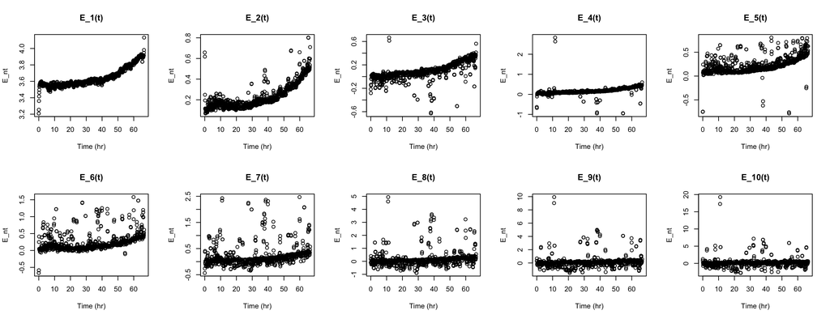

```r
par(mfrow = c(2,5))
for (n in 1:10){
  E_nt <- rowSums(sapply(1:n, log_choose, n=n, moments_expectations=moments_expectations_WT))
  plot(x = microMA_WT$time/60,
       y = E_nt,
       xlab = "Time (hr)",
       main = paste("E_", n, "(t)", sep = ""))
}
```

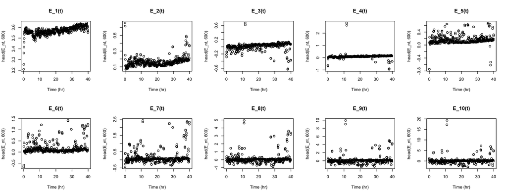

```r
par(mfrow = c(2,5))
for (n in 1:10){
  E_nt <- rowSums(sapply(1:n, log_choose, n=n, moments_expectations=moments_expectations_WT))
  plot(x = head(microMA_WT$time/60, 600),
       y = head(E_nt, 600),
       xlab = "Time (hr)",
       main = paste("E_", n, "(t)", sep = ""))
}
```

#### WT + MutH

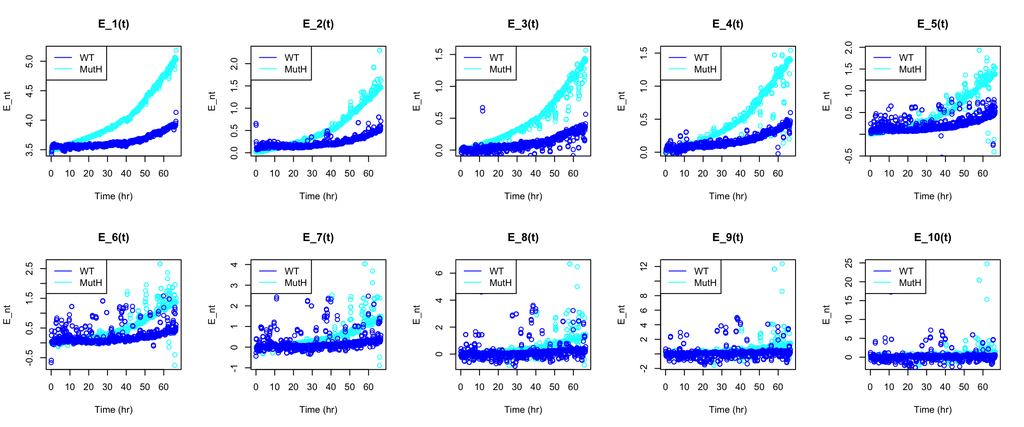

```r
par(mfrow = c(2,5))
for (n in 1:10){
  E_nt <- rowSums(sapply(1:n, log_choose, n=n, moments_expectations=moments_expectations_MutH))
  plot(x = microMA_MutH$time/60,
       y = E_nt,
       xlab = "Time (hr)",
       col = "cyan",
       main = paste("E_", n, "(t)", sep = ""))

  E_nt <- rowSums(sapply(1:n, log_choose, n=n, moments_expectations=moments_expectations_WT))
  points(x = microMA_WT$time/60,
       y = E_nt,
       xlab = "Time (hr)",
       col = "blue",
       main = paste("E_", n, "(t)", sep = ""))

  legend("topleft", legend = c("WT", "MutH"), col=c("blue", "cyan"), lty=1)
}
```

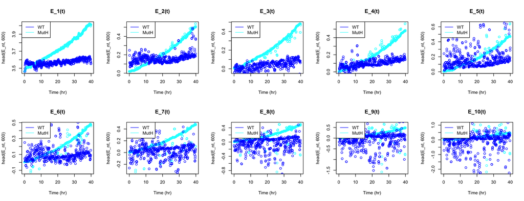

```r
par(mfrow = c(2,5))
for (n in 1:10){
  E_nt <- rowSums(sapply(1:n, log_choose, n=n, moments_expectations=moments_expectations_MutH))
  plot(x = head(microMA_MutH$time/60, 600),
       y = head(E_nt, 600),
       xlab = "Time (hr)",
       col = "cyan",
       main = paste("E_", n, "(t)", sep = ""))

  E_nt <- rowSums(sapply(1:n, log_choose, n=n, moments_expectations=moments_expectations_WT))
  points(x = head(microMA_WT$time/60, 600),
       y = head(E_nt, 600),
       xlab = "Time (hr)",
       col = "blue",
       main = paste("E_", n, "(t)", sep = ""))

  legend("topleft", legend = c("WT", "MutH"), col=c("blue", "cyan"), lty=1)
}
```